# Social_Capital_2_Simple_Modeling

Wesley_Tao

2018/5/21

```r
library(lme4)
```

```r
library(ggplot2)
library("mediation")
social.capital<-read.csv("../output/merged.csv")
head(social.capital)
```

```
##   GEO.id2       sk97       sk05       sk09     sk14
## 1    1001 -0.6846493 -0.7180735 -0.3267297 -0.63100
## 2    1003 -0.7399664 -0.8686748 -0.4229584 -0.55540
## 3    1005 -1.3885393 -1.4866061 -1.1965171 -0.89104
## 4    1007 -1.0582401 -1.5401705 -0.9510968 -0.90658
## 5    1009 -1.5416635 -1.4314892 -1.3039351 -1.01328
## 6    1011 -1.7685438 -1.4858298 -0.1007044 -0.50240
##         GEO.display.label Gini_Coefficient         County   State Jim_Crow
## 1 Autauga County, Alabama           0.4100 Autauga County Alabama     TRUE
## 2 Baldwin County, Alabama           0.4517 Baldwin County Alabama     TRUE
## 3 Barbour County, Alabama           0.4608 Barbour County Alabama     TRUE
## 4    Bibb County, Alabama           0.4365    Bibb County Alabama     TRUE
## 5  Blount County, Alabama           0.4134  Blount County Alabama     TRUE
## 6 Bullock County, Alabama           0.4460 Bullock County Alabama     TRUE
```

# Gini Coefficient

## Fixed Effect Model for Gini_coefficient

Question: Are jim_crow states and non_jim_crow states have different Gini_coefficient? Models: one-way anova
$$y_{ij}=\mu+\alpha_j+\epsilon_{ij}$$
$y_{ij}$represent the gini coefficient of county i in state j

$\mu$ stands for the grand mean

$\alpha_{j}$ stands for the dummy variable introduced by jim crow law state

```r
simple.one.way<-aov(Gini_Coefficient~Jim_Crow,data=social.capital)
summary(simple.one.way)
```

```
##               Df Sum Sq Mean Sq F value Pr(>F)
## Jim_Crow       1  0.241 0.24129   217.4 <2e-16 ***
## Residuals   3104  3.446 0.00111
## ---
## Signif. codes:  0 '***' 0.001 '**' 0.01 '*' 0.05 '.' 0.1 ' ' 1
```

Answers: Null hypothesis for this test is:
$$H_0 : \alpha =0 \space H_a: \alpha \neq 0$$
According to the summary statistics (Pr(>F)<0.0001) of this simple analysis, we conclude that jim_crow_states and non_jim_crow states have very different level of gini_coefficient.

## Random Effect for Gini_coefficient

In the previous model, all the counties are divided into 2 groups and within each group they are treated identical. Now we would like to capture the state variability in our model.

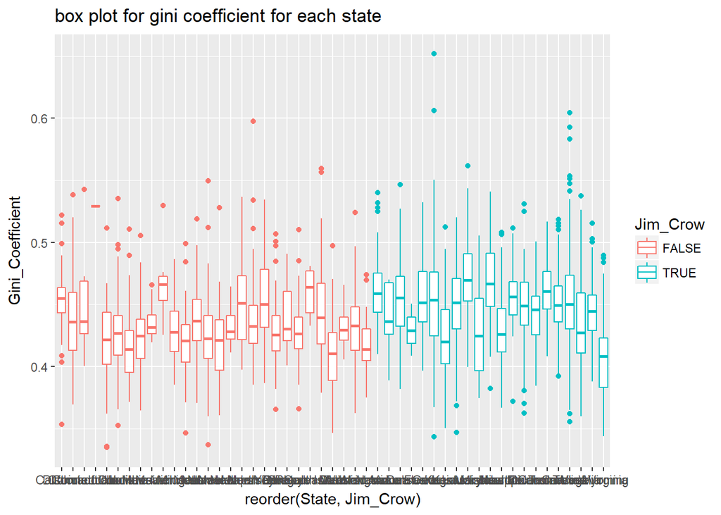

```r
this_oder<-order(social.capital$Jim_Crow,social.capital$State)
social.capital<-social.capital[this_oder,]
ggplot(data=social.capital)+
  geom_boxplot(aes(x=reorder(State,Jim_Crow),y=Gini_Coefficient,color=Jim_Crow))+
  labs(title="box plot for gini coefficient for each state")
```

We are going to introduce group specific random effect for each state in the model: which means the intercept for each states are different.
$$y_{ij}=\alpha_j+\beta_j+\epsilon_{ij}$$
$\beta_j$ stands for the intercept for group j $\alpha_j$ stands for the jim_crow dummy variable

```r
r.e.1<-lmer(Gini_Coefficient~Jim_Crow+(1|State),data=social.capital)
summary(r.e.1)
```

```
## Linear mixed model fit by REML ['lmerMod']
## Formula: Gini_Coefficient ~ Jim_Crow + (1 | State)
##    Data: social.capital
##
## REML criterion at convergence: -12620.1
##
## Scaled residuals:
##     Min      1Q  Median      3Q     Max
## -3.5834 -0.6280 -0.0724  0.5572  6.3496
##
## Random effects:
##  Groups   Name        Variance  Std.Dev.
##  State    (Intercept) 0.0001855 0.01362
##  Residual             0.0009652 0.03107
## Number of obs: 3106, groups:  State, 49
##
## Fixed effects:
##              Estimate Std. Error t value
## (Intercept)  0.434265   0.002828  153.57
## Jim_CrowTRUE 0.013058   0.004233    3.08
##
## Correlation of Fixed Effects:
##             (Intr)
## Jim_CrwTRUE -0.668
```

Interpretation: states with Jim_Crow label have a marginal increase 0.013 increase in Gini Coefficient

## Statistical significance

We need some sort of p values unfortunately p-values for mixed model are not straight forward as they are in linear models.  
I would like to introduce Likelihood Ratio Test as a means to attain P-values  
Null model: states with varying intercept without jim_crow Alternative model: with jim_crow

```r
gini.null<-lmer(Gini_Coefficient~(1|State),data=social.capital)
gini.alter<-lmer(Gini_Coefficient~Jim_Crow+(1|State),data=social.capital)
anova(gini.null,gini.alter)
```

```
## refitting model(s) with ML (instead of REML)
```

```
## Data: social.capital
## Models:
## gini.null: Gini_Coefficient ~ (1 | State)
## gini.alter: Gini_Coefficient ~ Jim_Crow + (1 | State)
##            Df    AIC    BIC logLik deviance  Chisq Chi Df Pr(>Chisq)
## gini.null   3 -12625 -12607 6315.6   -12631
## gini.alter  4 -12632 -12608 6319.9   -12640 8.6208      1   0.003323 **
## ---
## Signif. codes:  0 '***' 0.001 '**' 0.01 '*' 0.05 '.' 0.1 ' ' 1
```

Conclusion: Jim_crow dummy affect Gini Index ($\chi^2(1)=8.62 p=0.0033$) raising about 0.01 $\pm$ 0.004(standard errors)

# Social Capital index multilevel regression

We are going to do similar statistical test for social capital index for year 1997,2005,2009,2014 ## year 1997

```
## Linear mixed model fit by REML ['lmerMod']
## Formula: sk97 ~ Jim_Crow + (1 | State)
##    Data: df
##
## REML criterion at convergence: 8674
##
## Scaled residuals:
##     Min      1Q  Median      3Q     Max
## -4.8515 -0.5823 -0.0638  0.4796  7.8375
##
## Random effects:
##  Groups   Name        Variance Std.Dev.
##  State    (Intercept) 0.8193   0.9052
##  Residual             0.9009   0.9492
## Number of obs: 3106, groups:  State, 49
##
## Fixed effects:
##              Estimate Std. Error t value
## (Intercept)    0.4905     0.1761   2.785
## Jim_CrowTRUE  -1.0591     0.2670  -3.966
##
## Correlation of Fixed Effects:
##             (Intr)
## Jim_CrwTRUE -0.660
## likelihood ratio test for two models
```

```
## refitting model(s) with ML (instead of REML)
```

```
## Data: df
## Models:
## gini.null: sk97 ~ (1 | State)
## gini.alter: sk97 ~ Jim_Crow + (1 | State)
##            Df    AIC    BIC  logLik deviance Chisq Chi Df Pr(>Chisq)
## gini.null   3 8691.2 8709.3 -4342.6   8685.2
## gini.alter  4 8679.0 8703.2 -4335.5   8671.0 14.17      1   0.000167 ***
## ---
## Signif. codes:  0 '***' 0.001 '**' 0.01 '*' 0.05 '.' 0.1 ' ' 1
```

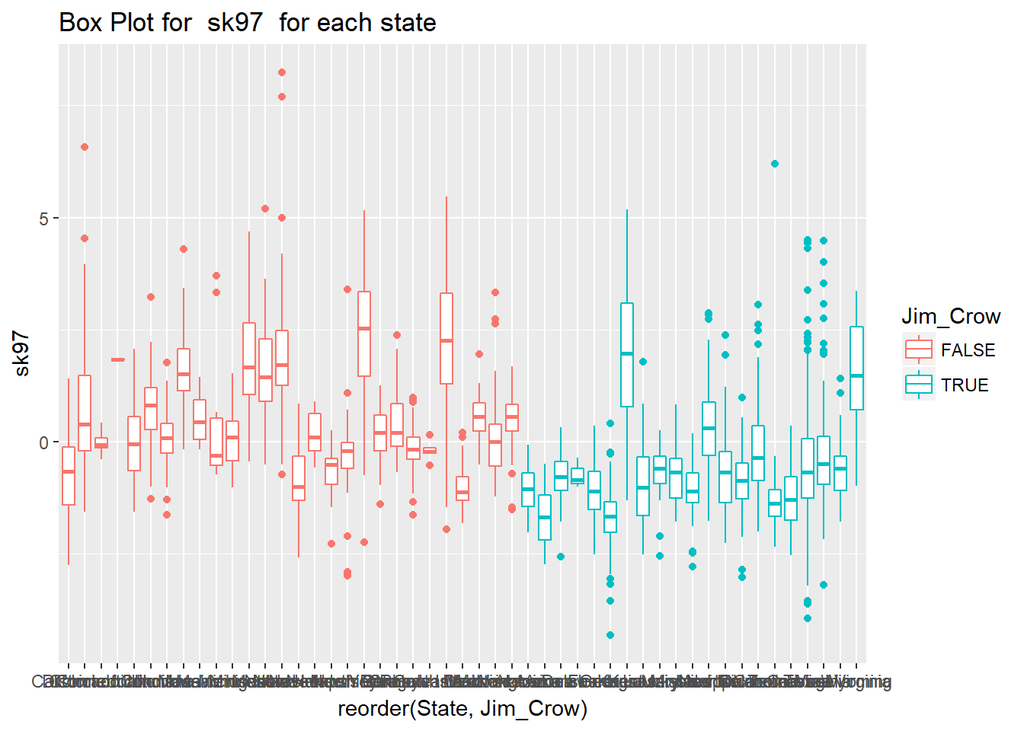

```r
multilevel.regression<-function(year,df){
  title.name<-paste("Box Plot for ",year," for each state")
  p<-ggplot(data=df,environment = environment())+
  geom_boxplot(aes_string(x="reorder(State,Jim_Crow)",y=year,color="Jim_Crow"))+
  labs(title=title.name)

  f.null<-as.formula(paste(year,"~(1|State)"))
  f.alter<-as.formula(paste(year,"~ Jim_Crow+(1|State)"))

  gini.null<-lmer(f.null,data=df)
  gini.alter<-lmer(f.alter,data=df)
  print(summary(gini.alter))
  cat("likelihood ratio test for two models")
  print(anova(gini.null,gini.alter))
  return(p)
}
multilevel.regression("sk97",social.capital)
```

# year 2005

```r
multilevel.regression("sk05",social.capital)
```

```
## Linear mixed model fit by REML ['lmerMod']
## Formula: sk05 ~ Jim_Crow + (1 | State)
##    Data: df
##
## REML criterion at convergence: 8909.6
##
## Scaled residuals:
##     Min      1Q  Median      3Q     Max
## -4.2379 -0.5557 -0.0479  0.4524 15.3294
##
## Random effects:
##  Groups   Name        Variance Std.Dev.
##  State    (Intercept) 0.7557   0.8693
##  Residual             0.9741   0.9870
## Number of obs: 3106, groups:  State, 49
##
## Fixed effects:
##              Estimate Std. Error t value
## (Intercept)    0.4595     0.1698   2.706
## Jim_CrowTRUE  -0.9753     0.2572  -3.791
##
## Correlation of Fixed Effects:
##             (Intr)
## Jim_CrwTRUE -0.660
## likelihood ratio test for two models
```

```
## refitting model(s) with ML (instead of REML)
```

```
## Data: df
## Models:
## gini.null: sk05 ~ (1 | State)
## gini.alter: sk05 ~ Jim_Crow + (1 | State)
##            Df    AIC    BIC  logLik deviance  Chisq Chi Df Pr(>Chisq)
## gini.null   3 8925.6 8943.7 -4459.8   8919.6
## gini.alter  4 8914.4 8938.6 -4453.2   8906.4 13.128      1  0.0002909 ***
## ---
## Signif. codes:  0 '***' 0.001 '**' 0.01 '*' 0.05 '.' 0.1 ' ' 1
```

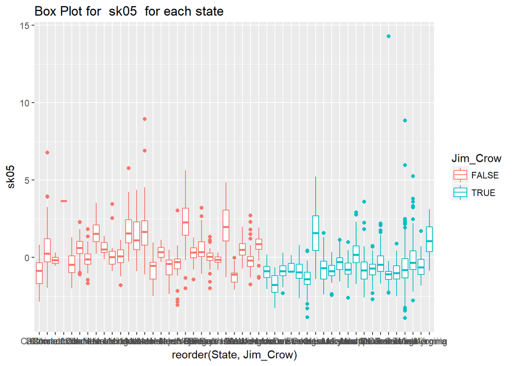

## year 2009

```r
multilevel.regression("sk09",social.capital)
```

```
## Linear mixed model fit by REML ['lmerMod']
## Formula: sk09 ~ Jim_Crow + (1 | State)
##    Data: df
##
## REML criterion at convergence: 9201.1
##
## Scaled residuals:
##     Min      1Q  Median      3Q     Max
## -3.9580 -0.5444 -0.0858  0.4147 17.0540
##
## Random effects:
##  Groups   Name        Variance Std.Dev.
##  State    (Intercept) 0.6659   0.816
##  Residual             1.0735   1.036
## Number of obs: 3106, groups:  State, 49
##
## Fixed effects:
##              Estimate Std. Error t value
## (Intercept)    0.3453     0.1604   2.152
## Jim_CrowTRUE  -0.7063     0.2427  -2.911
##
## Correlation of Fixed Effects:
##             (Intr)
## Jim_CrwTRUE -0.661
## likelihood ratio test for two models
```

```
## refitting model(s) with ML (instead of REML)
```

```
## Data: df
## Models:
## gini.null: sk09 ~ (1 | State)
## gini.alter: sk09 ~ Jim_Crow + (1 | State)
##            Df    AIC    BIC  logLik deviance  Chisq Chi Df Pr(>Chisq)
## gini.null   3 9211.8 9230.0 -4602.9   9205.8
## gini.alter  4 9205.7 9229.8 -4598.8   9197.7 8.1559      1   0.004292 **
## ---
## Signif. codes:  0 '***' 0.001 '**' 0.01 '*' 0.05 '.' 0.1 ' ' 1
```

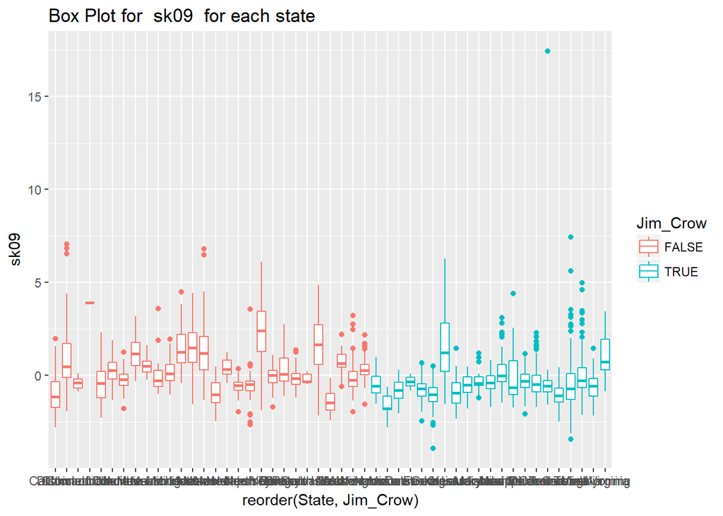

```r
multilevel.regression("sk14",social.capital)
```

```
## Linear mixed model fit by REML ['lmerMod']
## Formula: sk14 ~ Jim_Crow + (1 | State)
##    Data: df
##
## REML criterion at convergence: 9003.9
##
## Scaled residuals:
##     Min      1Q  Median      3Q     Max
## -4.0835 -0.5082 -0.0858  0.3984 21.5389
##
## Random effects:
##  Groups   Name        Variance Std.Dev.
##  State    (Intercept) 0.5827   0.7634
##  Residual             1.0084   1.0042
## Number of obs: 3106, groups:  State, 49
##
## Fixed effects:
##              Estimate Std. Error t value
## (Intercept)    0.3011     0.1504   2.002
## Jim_CrowTRUE  -0.5794     0.2274  -2.548
##
## Correlation of Fixed Effects:
##             (Intr)
## Jim_CrwTRUE -0.661
## likelihood ratio test for two models
```

```
## refitting model(s) with ML (instead of REML)
```

```
## Data: df
## Models:
## gini.null: sk14 ~ (1 | State)
## gini.alter: sk14 ~ Jim_Crow + (1 | State)
##            Df    AIC    BIC  logLik deviance  Chisq Chi Df Pr(>Chisq)
## gini.null   3 9012.6 9030.7 -4503.3   9006.6
## gini.alter  4 9008.3 9032.4 -4500.1   9000.3 6.3577      1    0.01169 *
## ---
## Signif. codes:  0 '***' 0.001 '**' 0.01 '*' 0.05 '.' 0.1 ' ' 1
```

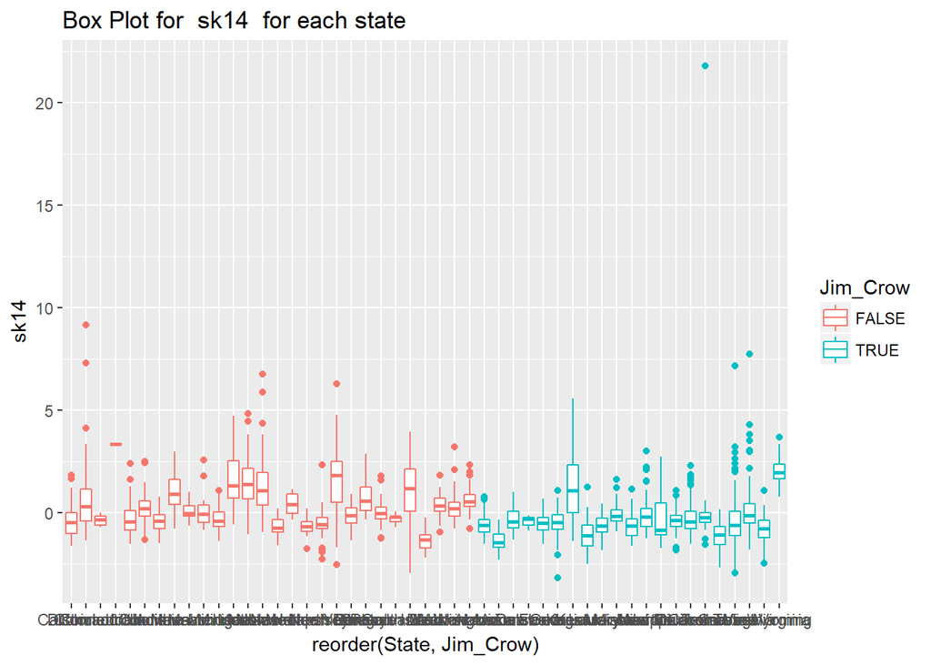

# Mediation analysis

Mediation analysis for Jim Crow Laws + Gini Coefficient –> Social Capital (2014)

```r
out.fit<-lm(sk14~Jim_Crow+Gini_Coefficient,data=social.capital)
med.fit<-lm(Gini_Coefficient~Jim_Crow,data=social.capital)
med.out<-mediation::mediate(med.fit,out.fit,treat = "Jim_Crow",mediator = "Gini_Coefficient")
summary(med.out)
```

```
##
## Causal Mediation Analysis
##
## Quasi-Bayesian Confidence Intervals
##
##                Estimate 95% CI Lower 95% CI Upper p-value
## ACME           -0.01871     -0.04224         0.00    0.09 .
## ADE            -0.70680     -0.79544        -0.62  <2e-16 ***
## Total Effect   -0.72552     -0.80835        -0.64  <2e-16 ***
## Prop. Mediated  0.02539     -0.00441         0.06    0.09 .
## ---
## Signif. codes:  0 '***' 0.001 '**' 0.01 '*' 0.05 '.' 0.1 ' ' 1
##
## Sample Size Used: 3106
##
##
## Simulations: 1000
```

This method is using simulation samples to construct the confidence interval for direct effect and mediate effect.

ADE stands for average direct effect
$$Direct\space Effect=Y_i(1,M_i(t))-Y_i(0,M_i(t)))$$

ACME means the average causal mediation effects
$$Mediation\space Effect=Y_i(t,M_i(1))-Y_i(t,M_i(0)))$$

$$Total\space Effect = Mediation \space Effect + Direct\space Effect$$

prop.mediated stands for the proportion of meidation effect. This is a ratio

```r
cat("Prop Mediated is a ratio of two estimates, which are known to have a very high variance especially when the average treatment effect is not precisely estimated.")
```

```
## Prop Mediated is a ratio of two estimates, which are known to have a very high variance especially when the average treatment effect is not precisely estimated.
```

```r
cat(" I would focus on the point estimate of this quantity rather than its CI.  The most important thing is the ACME which have a much more stable CI.")
```

```
##  I would focus on the point estimate of this quantity rather than its CI.  The most important thing is the ACME which have a much more stable CI.
```

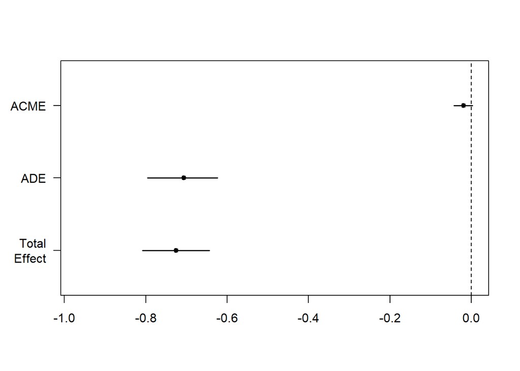

```r
plot(med.out)
```

```r
cat(" mediation effect is very small compared to direct effect. ")
```

```
##  mediation effect is very small compared to direct effect.
```